# Honduras transparency index

Craig Jolley

January 27, 2016

```r
setwd("C:/Users/Craig/Desktop/SMA/VSFS/LAPOP-SMA/indices")
lapop.2014.HND <- read.csv("../../HND-2014.csv")
```

- honqt1: Transparency of the presidency of the republic (1 = very, 4 = not at all)
- honqt2: Transparency of the National Congress
- honqt3: Transparency of the Government Accountability Office
- honqt4: Transparency of the state enterprises (ENEE, SANAA, HONDUTEL etc.)
- honqt5: Transparency of the police
- honqt6: Transparency of the Armed Forces
- honqt7: Transparency of the Public Ministry
- honqt8: Transparency of the National Anticorruption Council
- honqt9: Transparency of the municipal government
- honqt10: Transparency of the Superior Court of Accounts
- honqt11: Transparency of the Institute for Access to Public Information
- honqt12: Transparency of the Supreme Electoral Tribunal

```r
library(ggplot2)
library(mice)
library(plyr)
library(GGally)
set.seed(12345)
my_data <- lapop.2014.HND[,paste('honqt',1:12,sep='')]
is.na(my_data[my_data>800000]) <- TRUE

my_complete <- na.omit(my_data)
pr_complete <- prcomp(my_complete, center = TRUE, scale = FALSE)
# save this to plot later
s <- summary(pr_complete)
df <- data.frame(t(s$importance))
names(df) <- c('stdev','proportion','cum')
df$pc <- 1:nrow(df)
```

52% of total variance winds up in the first component.

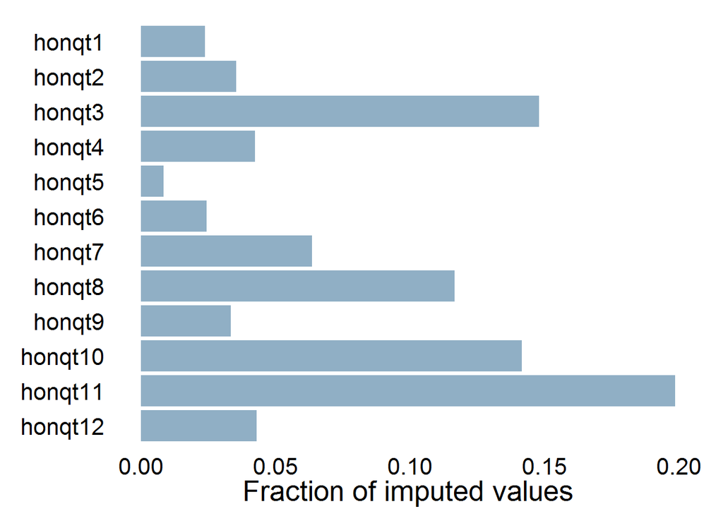

```r
my_imp <- mice(my_data, printFlag = F)
nmis <- my_imp$nmis
nm <- data.frame(nmis=nmis/nrow(my_data),var=names(nmis))
ggplot(nm,aes(x=factor(var,levels=rev(var)),y=nmis)) +
  geom_bar(stat = 'identity', fill = '#90AFC5') +
  ylab('Fraction of imputed values') +
  coord_flip() +
  theme_classic() +
  theme(legend.position='none',
        axis.ticks=element_blank(),
        axis.line=element_blank(),
        axis.title.y=element_blank(),
        text=element_text(size=20))
```

None of the variables have more than 20% missing; most everyone has an opinion about the police (`honqt5`) and fewer have one about the Institute for Access to Public Information (`honqt11`).

Now calculate PCA for each of the imputed datasets.

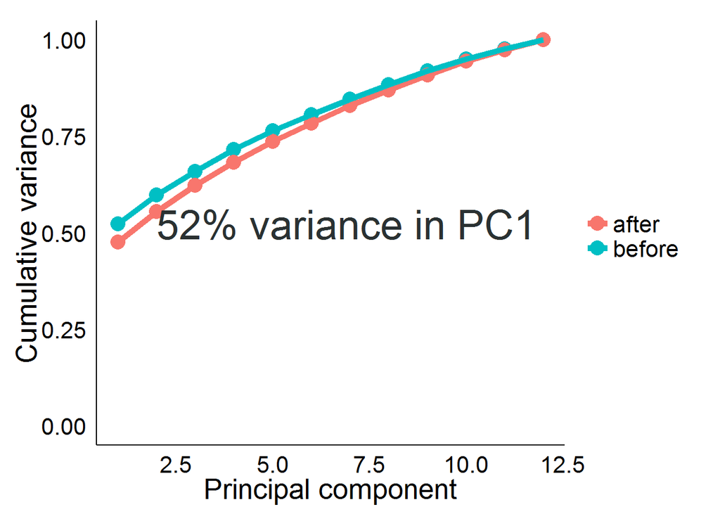

```r
pr <- lapply(1:5,function(x) prcomp(complete(my_imp,x),scale=FALSE,center=TRUE))
s1 <- summary(pr[[1]])
df1 <- data.frame(t(s1$importance))
names(df1) <- c('stdev','proportion','cum')
df1$pc <- 1:nrow(df1)
df1$group <- 'after'
df$group <- 'before'
df1 <- rbind(df,df1)
ggplot(df1,aes(x=pc,y=cum,color=group)) +
  geom_point(size=5) +
  geom_line(size=2) +
  scale_y_continuous(limits=c(0,1)) +
  xlab('Principal component') +
  ylab('Cumulative variance') +
  annotate('text',x=2,y=df$cum[1],hjust=0,size=10,color='#2A3132',
           label=paste(round(df$cum[1]*100),'% variance in PC1',sep='')) +
  theme_classic() +
  theme(legend.title=element_blank(),
        axis.ticks=element_blank(),
        text=element_text(size=20))
```

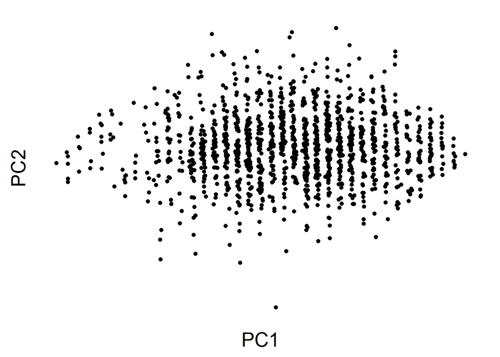

```r
PC1 <- pr[[1]]$x[,1]
PC2 <- pr[[1]]$x[,2]
qplot(PC1,PC2) +
  theme_classic() +
  theme(legend.position='none',
        axis.ticks=element_blank(),
        axis.text=element_blank(),
        axis.line=element_blank(),
        text=element_text(size=20))
```

PC1 is a little bit “stripy”, but still shows a decent distribution.

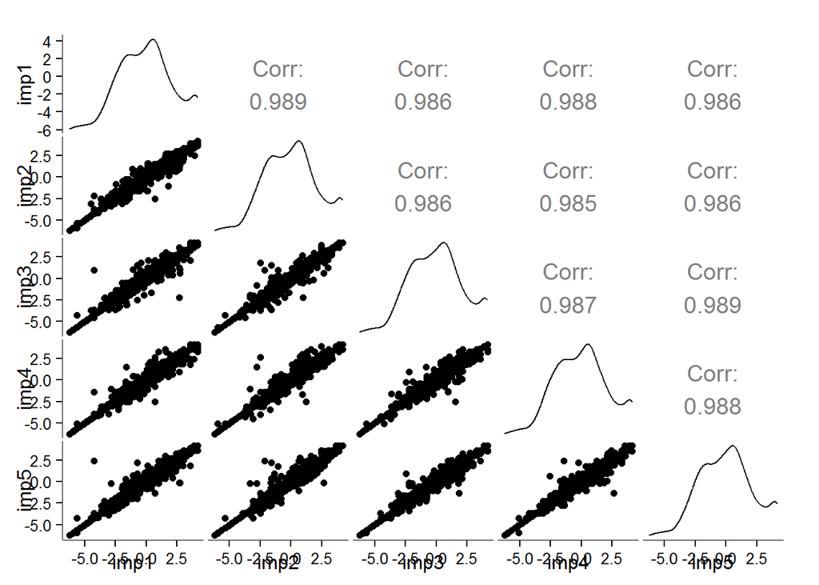

```r
all_pc1 <- data.frame(llply(1:5, function(i) pr[[i]]$x[,1]))
names(all_pc1) <- c('imp1', 'imp2', 'imp3', 'imp4', 'imp5')
ggpairs(all_pc1) + theme_classic()
```

Correlations between imputed datasets are high; distributions look good.

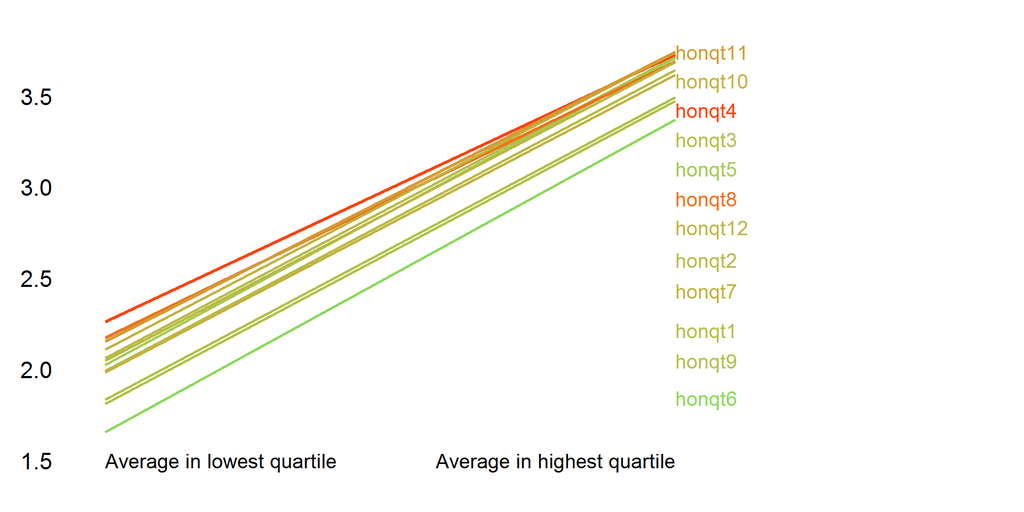

```r
all_pc1$avg <- rowMeans(all_pc1)
qchange <- data.frame(low=colMeans(my_data[all_pc1$avg < quantile(all_pc1$avg)[2],],na.rm=TRUE),
                      hi=colMeans(my_data[all_pc1$avg > quantile(all_pc1$avg)[4],],na.rm=TRUE))
qchange$slope <- qchange$hi - qchange$low
qchange$label <- rownames(qchange)
qchange$even <- rank(qchange$hi)/nrow(qchange)*max(qchange$hi)
ggplot(data=qchange) +
  geom_segment(aes(x=0,y=qchange$low,xend=1,yend=qchange$hi,
                   color=qchange$slope),size=1) +
  scale_color_gradient(low='#FF420E',high='#89DA59') +
  geom_text(aes(x=1,y=(qchange$even+qchange$hi)/2,label=qchange$label,
                hjust=0,color=qchange$slope),size=5) +
  annotate("text",x=0,y=1.5,label='Average in lowest quartile',hjust=0) +
  annotate("text",x=1,y=1.5,label='Average in highest quartile',hjust=1) +
  scale_x_continuous(limits=c(0,1.5)) +
  scale_y_continuous(limits=c(1.5,3.8)) +
  theme_classic() +
  theme(legend.position='none',
        axis.ticks=element_blank(),
        axis.line=element_blank(),
        axis.text.x=element_blank(),
        axis.title=element_blank(),
        text=element_text(size=20))
```

All values increase (toward less transparency) as the index increases – need to flip sign below.

```r
all_pc1$norm <- scale(-all_pc1$avg) # now high values mean more transparency
predict_data <- data.frame(honqt1=c(4,1))
for (i in 2:12) {
  predict_data[,paste('honqt',i,sep='')] <- predict_data$honqt1
}

minmax <- rowMeans(sapply(1:5, function(i) predict(pr[[i]],predict_data)[,1]))
minmax <- (mean(all_pc1$avg) - minmax) / sd(all_pc1$avg)
#quantile(all_pc1$norm)
trans <- data.frame(w=all_pc1$norm)
```

```r
predict_data2 <- data.frame(diag(ncol(predict_data)))
names(predict_data2) <- names(predict_data)
predict_data2 <- 4 - predict_data2
```

Now, in each row of predict_data2, all values are those that will give a lower score, except for one.

```r
scores <- rowMeans(sapply(1:5, function(i) predict(pr[[i]],predict_data2)[,1]))
scores <- (mean(all_pc1$avg)-scores)/sd(all_pc1$avg)
```

Now you can see that all of the scores are reasonably close to the minimum value stored in minmax.

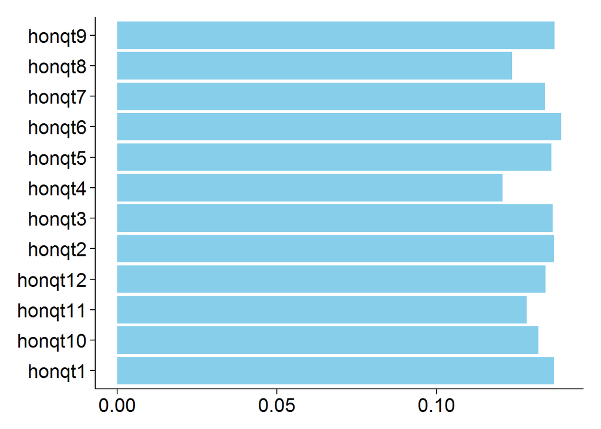

```r
diff <- data.frame(d=(scores-minmax[1]), n = names(predict_data))
ggplot(diff, aes(x=n,y=d)) +
  geom_bar(stat = 'identity', fill = 'skyblue') +
  coord_flip() +
  theme_classic() +
  theme(text = element_text(size=20),
        axis.title.y = element_blank(),
        axis.title.x = element_blank())
```

All variables have a nearly equal effect.

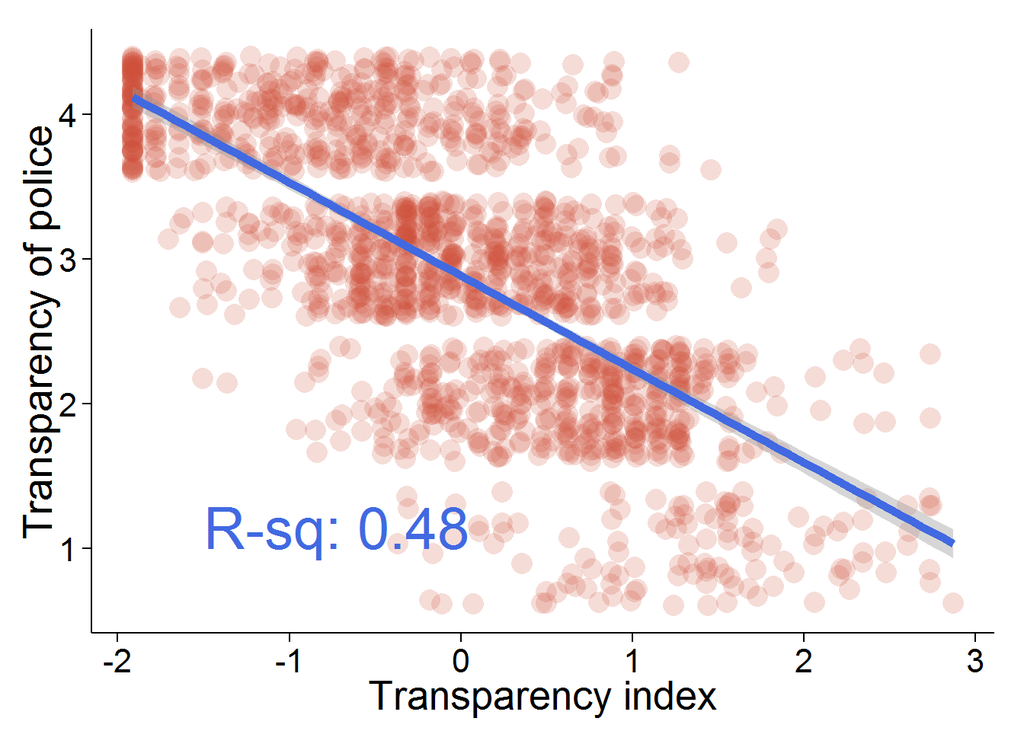

```r
honqt5 <- data.frame(q=my_data$honqt5,w=trans$w)
my_lm <- lm(data=honqt5, q ~ w)
ggplot(honqt5,aes(x=w,y=q)) +
  geom_jitter(color='tomato3',size=5,alpha=0.2) +
  theme_classic() +
  geom_smooth(method='lm',size=2,color='royalblue') +
  annotate('text',label=paste("R-sq:",round(summary(my_lm)$r.squared,2)),
  size=10,x=-1.5,y=1,hjust=0,vjust=0,color='royalblue') +
  ylab('Transparency of police') +
  xlab('Transparency index') +
  theme(text=element_text(size=20))
```

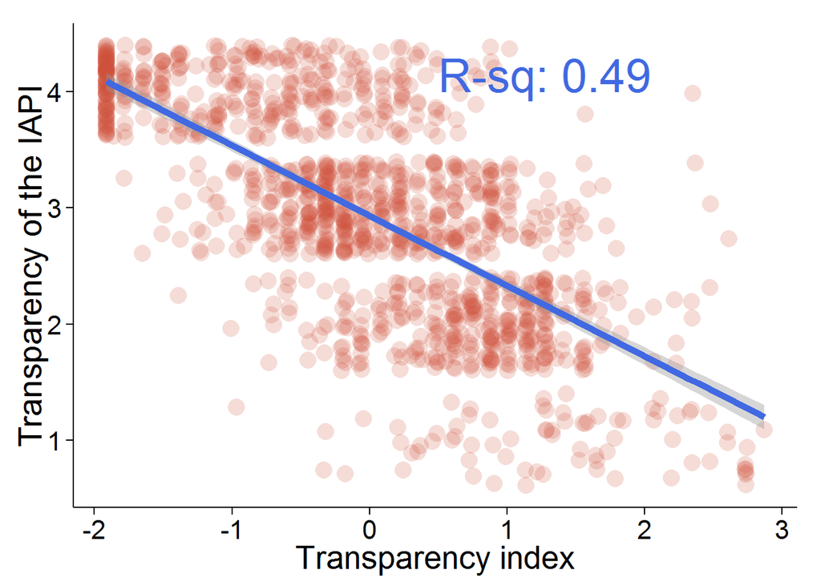

```r
honqt11 <- data.frame(q=my_data$honqt11,w=trans$w)
my_lm <- lm(data=honqt11, q ~ w)
ggplot(honqt11,aes(x=w,y=q)) +
  geom_jitter(color='tomato3',size=5,alpha=0.2) +
  theme_classic() +
  geom_smooth(method='lm',size=2,color='royalblue') +
  annotate('text',label=paste("R-sq:",round(summary(my_lm)$r.squared,2)),
  size=10,x=0.5,y=4,hjust=0,vjust=0,color='royalblue') +
  ylab('Transparency of the IAPI') +
  xlab('Transparency index') +
  theme(text=element_text(size=20))
```

Test significance of correlations between the index and the component variables using linear regression.

```r
lmp <- function (modelobject) {
  if (class(modelobject) != "lm") stop("Not an object of class 'lm' ")
    f <- summary(modelobject)$fstatistic
    p <- pf(f[1],f[2],f[3],lower.tail=F)
    attributes(p) <- NULL
    return(p)
}
sapply(my_data, function(x) lmp(lm(x ~ all_pc1$norm)))
```

```
##        honqt1        honqt2        honqt3        honqt4        honqt5
## 1.174992e-217 4.650437e-245 1.731767e-236 1.756744e-168 3.298992e-223
##        honqt6        honqt7        honqt8        honqt9       honqt10
## 1.443119e-195 6.374080e-233 4.360289e-184 1.368691e-201 7.566997e-226
##       honqt11       honqt12
## 3.216193e-184 1.212037e-212
```

All are highly significant.